# Assessment1

Shoyeb Mohammed - s4633055

03/03/2022

# RMarkdown *editing*

R markdown is a file format for making dynamic documents with R. It is the best way to present your work done with R. You can make a HTML, PDF or Word document by clicking “knit” and selecting your document type.

#### 5. Inster an in-text link:

[Click Here!](https://rmarkdown.rstudio.com/lesson-8.html) to go to the lesson 8.

#### 6. Insert an R chunck and create a variable with this dataset:

```r
fastfood <- read.csv("https://raw.githubusercontent.com/rfordatascience/tidytuesday/master/data/2018/2018-09-04/fastfood_calories.csv")
```

#### 7. Display first 10 rows useing head() and kable()

```r
# install.packages("knitr")
library(knitr)

head(fastfood, 10)
```

```
##     X restaurant                                      item calories cal_fat
## 1   1  Mcdonalds          Artisan Grilled Chicken Sandwich      380      60
## 2   2  Mcdonalds            Single Bacon Smokehouse Burger      840     410
## 3   3  Mcdonalds            Double Bacon Smokehouse Burger     1130     600
## 4   4  Mcdonalds Grilled Bacon Smokehouse Chicken Sandwich      750     280
## 5   5  Mcdonalds  Crispy Bacon Smokehouse Chicken Sandwich      920     410
## 6   6  Mcdonalds                                   Big Mac      540     250
## 7   7  Mcdonalds                              Cheeseburger      300     100
## 8   8  Mcdonalds                  Classic Chicken Sandwich      510     210
## 9   9  Mcdonalds                       Double Cheeseburger      430     190
## 10 10  Mcdonalds      Double Quarter PounderÂ® with Cheese      770     400
##    total_fat sat_fat trans_fat cholesterol sodium total_carb fiber sugar
## 1          7       2       0.0          95   1110         44     3    11
## 2         45      17       1.5         130   1580         62     2    18
## 3         67      27       3.0         220   1920         63     3    18
```

[output cut: 18 more lines]

```r
kable(fastfood[1:5,])
```

| X | restaurant | item | calories | cal_fat | total_fat | sat_fat | trans_fat | cholesterol | sodium | total_carb | fiber | sugar | protein | vit_a | vit_c | calcium | salad |
| --- | --- | --- | --- | --- | --- | --- | --- | --- | --- | --- | --- | --- | --- | --- | --- | --- | --- |
| 1 | Mcdonalds | Artisan Grilled Chicken Sandwich | 380 | 60 | 7 | 2 | 0.0 | 95 | 1110 | 44 | 3 | 11 | 37 | 4 | 20 | 20 | Other |
| 2 | Mcdonalds | Single Bacon Smokehouse Burger | 840 | 410 | 45 | 17 | 1.5 | 130 | 1580 | 62 | 2 | 18 | 46 | 6 | 20 | 20 | Other |
| 3 | Mcdonalds | Double Bacon Smokehouse Burger | 1130 | 600 | 67 | 27 | 3.0 | 220 | 1920 | 63 | 3 | 18 | 70 | 10 | 20 | 50 | Other |
| 4 | Mcdonalds | Grilled Bacon Smokehouse Chicken Sandwich | 750 | 280 | 31 | 10 | 0.5 | 155 | 1940 | 62 | 2 | 18 | 55 | 6 | 25 | 20 | Other |
| 5 | Mcdonalds | Crispy Bacon Smokehouse Chicken Sandwich | 920 | 410 | 45 | 12 | 0.5 | 120 | 1980 | 81 | 4 | 18 | 46 | 6 | 20 | 20 | Other |

### End of the part 1

# Part - 2

#### 8. Display the observations that has more than 1000 calories.

```r
library(dplyr)
fastfood %>% filter(calories > 1000) -> cal

kable(cal[1:10,])
```

| X | restaurant | item | calories | cal_fat | total_fat | sat_fat | trans_fat | cholesterol | sodium | total_carb | fiber | sugar | protein | vit_a | vit_c | calcium | salad |
| --- | --- | --- | --- | --- | --- | --- | --- | --- | --- | --- | --- | --- | --- | --- | --- | --- | --- |
| 3 | Mcdonalds | Double Bacon Smokehouse Burger | 1130 | 600 | 67 | 27 | 3.0 | 220 | 1920 | 63 | 3 | 18 | 70 | 10 | 20 | 50 | Other |
| 38 | Mcdonalds | 10 piece Buttermilk Crispy Chicken Tenders | 1210 | 630 | 70 | 12 | 1.0 | 240 | 3230 | 52 | 1 | 4 | 94 | 0 | 0 | 4 | Other |
| 39 | Mcdonalds | 12 piece Buttermilk Crispy Chicken Tenders | 1510 | 790 | 88 | 15 | 1.0 | 295 | 3770 | 64 | 1 | 2 | 115 | 0 | 2 | 6 | Other |
| 40 | Mcdonalds | 20 piece Buttermilk Crispy Chicken Tenders | 2430 | 1270 | 141 | 24 | 2.0 | 475 | 6080 | 103 | 2 | 3 | 186 | 0 | 2 | 8 | Other |
| 45 | Mcdonalds | 40 piece Chicken McNuggets | 1770 | 960 | 107 | 18 | 0.5 | 295 | 3370 | 105 | 7 | 1 | 98 | 0 | 15 | 6 | Other |
| 48 | Mcdonalds | 10 piece Sweet N’ Spicy Honey BBQ Glazed Tenders | 1600 | 600 | 66 | 10 | 0.0 | 265 | 4450 | 156 | 5 | 87 | 97 | 8 | 40 | 10 | Other |
| 99 | Sonic | Super Sonic Bacon Double Cheeseburger (w/mayo) | 1280 | 830 | 92 | 36 | 4.0 | 260 | 1630 | 44 | 2 | 7 | 67 | 15 | 6 | 40 | Other |
| 100 | Sonic | Super Sonic Double Cheeseburger W/ Mustard | 1120 | 680 | 76 | 32 | 4.0 | 235 | 1550 | 44 | 2 | 8 | 63 | 15 | 8 | 40 | Other |
| 101 | Sonic | Super Sonic Double Cheeseburger W/ Ketchup | 1130 | 680 | 76 | 32 | 4.0 | 235 | 1620 | 47 | 2 | 11 | 63 | 20 | 10 | 40 | Other |
| 102 | Sonic | Super Sonic Double Cheeseburger W/ Mayo | 1220 | 780 | 87 | 34 | 4.0 | 245 | 1520 | 45 | 2 | 8 | 63 | 15 | 8 | 40 | Other |

#### 9. Arrange observations with total_fat > 40, total_carb > 80, in descending order.

```r
library(dplyr)

fastfood %>% filter(total_fat > 40, total_carb > 80) -> dont_eat_this

arrange(dont_eat_this, desc(total_carb))
```

```
##      X  restaurant                                             item calories
## 1   48   Mcdonalds 10 piece Sweet N' Spicy Honey BBQ Glazed Tenders     1600
## 2  123       Sonic        5 Piece Super Crunch Chicken Strip Dinner     1190
## 3  271 Dairy Queen    6 Piece Chicken Strip Basket w/ Country Gravy     1260
## 4  122       Sonic        4 Piece Super Crunch Chicken Strip Dinner     1080
## 5  121       Sonic        3 Piece Super Crunch Chicken Strip Dinner      970
## 6   45   Mcdonalds                       40 piece Chicken McNuggets     1770
## 7  270 Dairy Queen    4 Piece Chicken Strip Basket w/ Country Gravy     1030
## 8   40   Mcdonalds       20 piece Buttermilk Crispy Chicken Tenders     2430
## 9  291 Dairy Queen                              Steak Finger Basket      910
## 10 310      Subway                        Footlong Big Hot Pastrami     1160
## 11 321      Subway              Footlong Chicken & Bacon Ranch Melt     1140
## 12 331      Subway                            Footlong Italian Hero     1100
## 13 363      Subway   Footlong Turkey Italiano Melt (with Provolone)      980
## 14 431   Taco Bell                 XXL Grilled Stuft Burrito - Beef      880
```

[output cut: 48 more lines]

```r
kable(dont_eat_this[1:10,])
```

| X | restaurant | item | calories | cal_fat | total_fat | sat_fat | trans_fat | cholesterol | sodium | total_carb | fiber | sugar | protein | vit_a | vit_c | calcium | salad |
| --- | --- | --- | --- | --- | --- | --- | --- | --- | --- | --- | --- | --- | --- | --- | --- | --- | --- |
| 5 | Mcdonalds | Crispy Bacon Smokehouse Chicken Sandwich | 920 | 410 | 45 | 12 | 0.5 | 120 | 1980 | 81 | 4 | 18 | 46 | 6 | 20 | 20 | Other |
| 40 | Mcdonalds | 20 piece Buttermilk Crispy Chicken Tenders | 2430 | 1270 | 141 | 24 | 2.0 | 475 | 6080 | 103 | 2 | 3 | 186 | 0 | 2 | 8 | Other |
| 45 | Mcdonalds | 40 piece Chicken McNuggets | 1770 | 960 | 107 | 18 | 0.5 | 295 | 3370 | 105 | 7 | 1 | 98 | 0 | 15 | 6 | Other |
| 48 | Mcdonalds | 10 piece Sweet N’ Spicy Honey BBQ Glazed Tenders | 1600 | 600 | 66 | 10 | 0.0 | 265 | 4450 | 156 | 5 | 87 | 97 | 8 | 40 | 10 | Other |
| 121 | Sonic | 3 Piece Super Crunch Chicken Strip Dinner | 970 | 410 | 46 | 8 | 1.0 | 55 | 2160 | 109 | 7 | 9 | 30 | 1 | 6 | 13 | Other |
| 122 | Sonic | 4 Piece Super Crunch Chicken Strip Dinner | 1080 | 460 | 51 | 9 | 1.0 | 75 | 2390 | 118 | 8 | 9 | 37 | 1 | 7 | 13 | Other |
| 123 | Sonic | 5 Piece Super Crunch Chicken Strip Dinner | 1190 | 510 | 57 | 10 | 1.0 | 90 | 2610 | 126 | 8 | 9 | 44 | 2 | 8 | 14 | Other |
| 161 | Arbys | Pecan Chicken Salad Sandwich | 840 | 400 | 44 | 6 | 0.5 | 75 | 1210 | 81 | 6 | 20 | 33 | 10 | 8 | 25 | Other |
| 176 | Arbys | Triple Decker Sandwich | 1030 | 459 | 51 | 17 | 1.0 | 155 | 2940 | 83 | 5 | 19 | 62 | NA | NA | NA | Other |
| 270 | Dairy Queen | 4 Piece Chicken Strip Basket w/ Country Gravy | 1030 | 480 | 53 | 9 | 1.0 | 80 | 2780 | 105 | 9 | 4 | 35 | 2 | 0 | 10 | Other |

#### 10. Using the fastfood data set - create a variable “heavy_food”; calories > 500 ~ “heavy” calories < 250 ~ “low”, average for all other cases.

###### To make the data tidy I have eliminated the other variables as the question only asks for calories and new variable heavy_food

```r
fastfood %>% select ("restaurant", "item", "calories") %>% mutate(heavy_food = case_when(calories > 500 ~ "heavy", calories < 250 ~ "low", T ~ "average")) -> h1

iris <- as_tibble(iris)

kable(h1[1:10,])
```

| restaurant | item | calories | heavy_food |
| --- | --- | --- | --- |
| Mcdonalds | Artisan Grilled Chicken Sandwich | 380 | average |
| Mcdonalds | Single Bacon Smokehouse Burger | 840 | heavy |
| Mcdonalds | Double Bacon Smokehouse Burger | 1130 | heavy |
| Mcdonalds | Grilled Bacon Smokehouse Chicken Sandwich | 750 | heavy |
| Mcdonalds | Crispy Bacon Smokehouse Chicken Sandwich | 920 | heavy |
| Mcdonalds | Big Mac | 540 | heavy |
| Mcdonalds | Cheeseburger | 300 | average |
| Mcdonalds | Classic Chicken Sandwich | 510 | heavy |
| Mcdonalds | Double Cheeseburger | 430 | average |
| Mcdonalds | Double Quarter PounderÂ® with Cheese | 770 | heavy |

#### 11. Display the types of variables in the dataset using “skimr” package.

```r
library(skimr)

skim(fastfood)
```

Data summary

| Name | fastfood |
| --- | --- |
| Number of rows | 515 |
| Number of columns | 18 |
| _______________________ |  |
| Column type frequency: |  |
| character | 3 |
| numeric | 15 |
| ________________________ |  |
| Group variables | None |

**Variable type: character**

| skim_variable | n_missing | complete_rate | min | max | empty | n_unique | whitespace |
| --- | --- | --- | --- | --- | --- | --- | --- |
| restaurant | 0 | 1 | 5 | 11 | 0 | 8 | 0 |
| item | 0 | 1 | 5 | 63 | 0 | 505 | 0 |
| salad | 0 | 1 | 5 | 5 | 0 | 1 | 0 |

**Variable type: numeric**

| skim_variable | n_missing | complete_rate | mean | sd | p0 | p25 | p50 | p75 | p100 | hist |
| --- | --- | --- | --- | --- | --- | --- | --- | --- | --- | --- |
| X | 0 | 1.00 | 258.00 | 148.81 | 1 | 129.5 | 258.0 | 386.5 | 515 | ▇▇▇▇▇ |
| calories | 0 | 1.00 | 530.91 | 282.44 | 20 | 330.0 | 490.0 | 690.0 | 2430 | ▇▆▁▁▁ |
| cal_fat | 0 | 1.00 | 238.81 | 166.41 | 0 | 120.0 | 210.0 | 310.0 | 1270 | ▇▃▁▁▁ |
| total_fat | 0 | 1.00 | 26.59 | 18.41 | 0 | 14.0 | 23.0 | 35.0 | 141 | ▇▃▁▁▁ |
| sat_fat | 0 | 1.00 | 8.15 | 6.42 | 0 | 4.0 | 7.0 | 11.0 | 47 | ▇▃▁▁▁ |
| trans_fat | 0 | 1.00 | 0.47 | 0.84 | 0 | 0.0 | 0.0 | 1.0 | 8 | ▇▁▁▁▁ |
| cholesterol | 0 | 1.00 | 72.46 | 63.16 | 0 | 35.0 | 60.0 | 95.0 | 805 | ▇▁▁▁▁ |
| sodium | 0 | 1.00 | 1246.74 | 689.95 | 15 | 800.0 | 1110.0 | 1550.0 | 6080 | ▇▆▁▁▁ |
| total_carb | 0 | 1.00 | 45.66 | 24.88 | 0 | 28.5 | 44.0 | 57.0 | 156 | ▅▇▂▁▁ |
| fiber | 12 | 0.98 | 4.14 | 3.04 | 0 | 2.0 | 3.0 | 5.0 | 17 | ▇▅▂▁▁ |
| sugar | 0 | 1.00 | 7.26 | 6.76 | 0 | 3.0 | 6.0 | 9.0 | 87 | ▇▁▁▁▁ |
| protein | 1 | 1.00 | 27.89 | 17.68 | 1 | 16.0 | 24.5 | 36.0 | 186 | ▇▂▁▁▁ |
| vit_a | 214 | 0.58 | 18.86 | 31.38 | 0 | 4.0 | 10.0 | 20.0 | 180 | ▇▁▁▁▁ |
| vit_c | 210 | 0.59 | 20.17 | 30.59 | 0 | 4.0 | 10.0 | 30.0 | 400 | ▇▁▁▁▁ |
| calcium | 210 | 0.59 | 24.85 | 25.52 | 0 | 8.0 | 20.0 | 30.0 | 290 | ▇▁▁▁▁ |

#### 12. Present the count observations from each resturant in a descending order and show the item count.

```r
fastfood %>% count(restaurant, sort = T)
```

```
##    restaurant   n
## 1   Taco Bell 115
## 2      Subway  96
## 3 Burger King  70
## 4   Mcdonalds  57
## 5       Arbys  55
## 6       Sonic  53
## 7 Dairy Queen  42
## 8 Chick Fil-A  27
```

```r
fastfood %>% count(item)
```

```
##                                                                item n
## 1                                            1 Piece Chick-n-Strips 1
## 2                                1/2 lb. FlameThrowerÂ® GrillBurger 1
## 3                                   1/2 lb. GrillBurger with Cheese 1
## 4                                    1/2 lb.* Cheesy Potato Burrito 1
## 5                                            1/2 lb.* Combo Burrito 1
## 6                                  1/4 lb. Bacon Cheese GrillBurger 1
## 7                                   1/4 lb. GrillBurger with Cheese 1
## 8                                1/4 lb. Mushroom Swiss GrillBurger 1
## 9                        10 piece Buttermilk Crispy Chicken Tenders 1
## 10                                       10 Piece Chicken McNuggets 1
## 11                 10 piece Sweet N' Spicy Honey BBQ Glazed Tenders 1
## 12                       12 piece Buttermilk Crispy Chicken Tenders 1
## 13                                         12 piece Chicken Nuggets 1
## 14                                 12 Piece Grilled Chicken Nuggets 1
```

[output cut: 491 more lines]

#### 13. Using grouping, summarise and display the average number of calories for each resturant.

```r
fastfood %>% group_by(restaurant) -> average_calories

average_calories %>% summarise(calories = mean(calories)) %>% kable()
```

| restaurant | calories |
| --- | --- |
| Arbys | 532.7273 |
| Burger King | 608.5714 |
| Chick Fil-A | 384.4444 |
| Dairy Queen | 520.2381 |
| Mcdonalds | 640.3509 |
| Sonic | 631.6981 |
| Subway | 503.0208 |
| Taco Bell | 443.6522 |

#### 14. Add variables to dataset, which:

##### - “average_calories”

```r
fastfood %>% group_by(restaurant) -> rest_grp

rest_grp %>% summarise(calories = mean(calories)) %>% kable() -> average_calories

library(base)

names(average_calories) <- c("Restaurants", "Avg_calories")

average_calories
```

| restaurant | calories |
| --- | --- |
| Arbys | 532.7273 |
| Burger King | 608.5714 |
| Chick Fil-A | 384.4444 |
| Dairy Queen | 520.2381 |
| Mcdonalds | 640.3509 |
| Sonic | 631.6981 |
| Subway | 503.0208 |
| Taco Bell | 443.6522 |

##### - “max_fat”

```r
max_fat <- rest_grp %>% summarise(total_fat = max(total_fat)) %>% kable()

names(max_fat) <- c("Restaurants","Max_fat")

max_fat
```

| restaurant | total_fat |
| --- | --- |
| Arbys | 59 |
| Burger King | 126 |
| Chick Fil-A | 47 |
| Dairy Queen | 75 |
| Mcdonalds | 141 |
| Sonic | 100 |
| Subway | 62 |
| Taco Bell | 42 |

##### - “min_cholesterol”

```r
min_cholesterol <- rest_grp %>% summarise(cholesterol = min(cholesterol)) %>% kable()

names(min_cholesterol) <- c("Restaurants","Min_cholesterol")

min_cholesterol
```

| restaurant | cholesterol |
| --- | --- |
| Arbys | 15 |
| Burger King | 5 |
| Chick Fil-A | 25 |
| Dairy Queen | 0 |
| Mcdonalds | 0 |
| Sonic | 0 |
| Subway | 0 |
| Taco Bell | 0 |

#### 15. Display the data vis of total fat per each type of restaurant. Write (2-3 sentences) why you believe this type of data vis present such information best.

Why Bar chart?

Bar chart is the best option to plot a graph to show the dynamics of variables on an axis where the other axis holds the discreet characters.

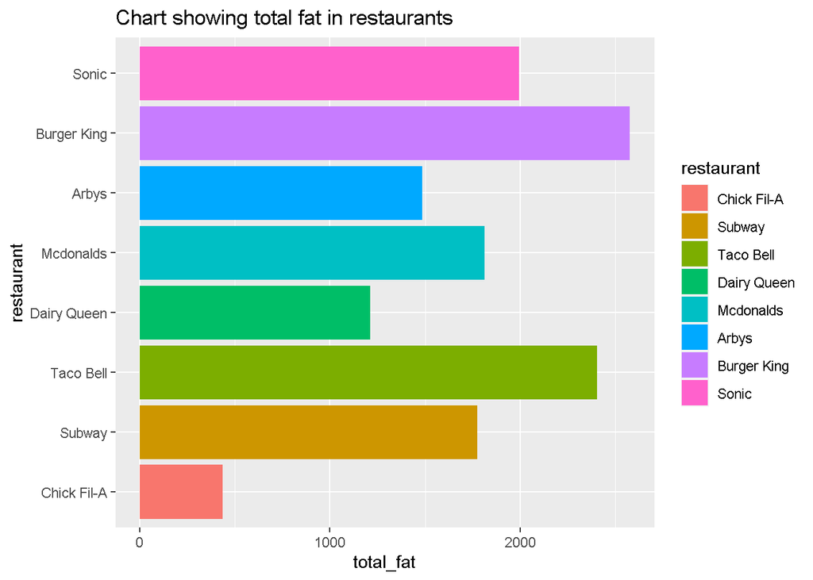

```r
library(forcats)
library(dplyr)
library(knitr)
library(ggplot2)

fastfood %>%
  mutate(restaurant = fct_reorder(restaurant, total_fat)) %>%
  ggplot(aes(restaurant, total_fat, fill = restaurant)) +
  geom_col() + coord_flip() +
  labs(title = "Chart showing total fat in restaurants")
```

#### 16. Add a variable to the dataset, which calculates the sum of cholesterol and sodium and anme it “cholestrol_sodium” - also remove “salad” variable.

To make the data tidy, I have eliminated the other variables from the data on purpose.

```r
fastfood %>% select ("restaurant", "item", "cholesterol", "sodium") %>% mutate(cholesterol_sodium = cholesterol + sodium, "salad" = NULL) -> c1

kable(c1[1:10,])
```

| restaurant | item | cholesterol | sodium | cholesterol_sodium |
| --- | --- | --- | --- | --- |
| Mcdonalds | Artisan Grilled Chicken Sandwich | 95 | 1110 | 1205 |
| Mcdonalds | Single Bacon Smokehouse Burger | 130 | 1580 | 1710 |
| Mcdonalds | Double Bacon Smokehouse Burger | 220 | 1920 | 2140 |
| Mcdonalds | Grilled Bacon Smokehouse Chicken Sandwich | 155 | 1940 | 2095 |
| Mcdonalds | Crispy Bacon Smokehouse Chicken Sandwich | 120 | 1980 | 2100 |
| Mcdonalds | Big Mac | 80 | 950 | 1030 |
| Mcdonalds | Cheeseburger | 40 | 680 | 720 |
| Mcdonalds | Classic Chicken Sandwich | 65 | 1040 | 1105 |
| Mcdonalds | Double Cheeseburger | 85 | 1040 | 1125 |
| Mcdonalds | Double Quarter PounderÂ® with Cheese | 175 | 1290 | 1465 |

#### 17. Use observations for McDonalds to plot sugar variable against protine with “geom_point().

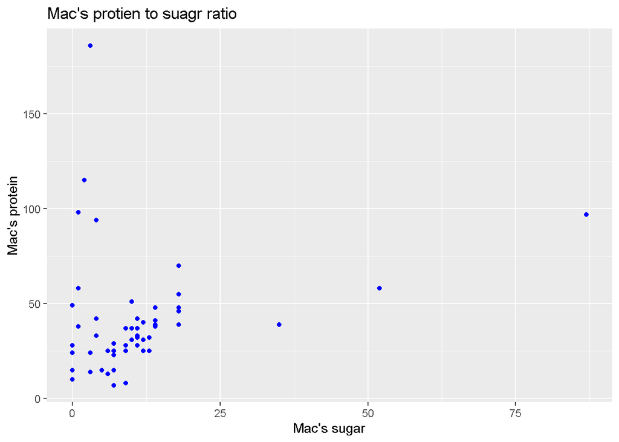

```r
fastfood %>% select("restaurant", "sugar", "protein") %>%
  filter( restaurant == "Mcdonalds") %>%
  ggplot(aes(sugar, protein)) +
  geom_point(col = "blue") +
  labs(x = "Mac's sugar", y = "Mac's protein",
       title = "Mac's protien to suagr ratio")
```

## End of part 2

#### 18. Identify variables which should be factors and transform their type into a factor variable.

```r
library(skimr)

skim(fastfood)
```

Data summary

| Name | fastfood |
| --- | --- |
| Number of rows | 515 |
| Number of columns | 18 |
| _______________________ |  |
| Column type frequency: |  |
| character | 3 |
| numeric | 15 |
| ________________________ |  |
| Group variables | None |

**Variable type: character**

| skim_variable | n_missing | complete_rate | min | max | empty | n_unique | whitespace |
| --- | --- | --- | --- | --- | --- | --- | --- |
| restaurant | 0 | 1 | 5 | 11 | 0 | 8 | 0 |
| item | 0 | 1 | 5 | 63 | 0 | 505 | 0 |
| salad | 0 | 1 | 5 | 5 | 0 | 1 | 0 |

**Variable type: numeric**

| skim_variable | n_missing | complete_rate | mean | sd | p0 | p25 | p50 | p75 | p100 | hist |
| --- | --- | --- | --- | --- | --- | --- | --- | --- | --- | --- |
| X | 0 | 1.00 | 258.00 | 148.81 | 1 | 129.5 | 258.0 | 386.5 | 515 | ▇▇▇▇▇ |
| calories | 0 | 1.00 | 530.91 | 282.44 | 20 | 330.0 | 490.0 | 690.0 | 2430 | ▇▆▁▁▁ |
| cal_fat | 0 | 1.00 | 238.81 | 166.41 | 0 | 120.0 | 210.0 | 310.0 | 1270 | ▇▃▁▁▁ |
| total_fat | 0 | 1.00 | 26.59 | 18.41 | 0 | 14.0 | 23.0 | 35.0 | 141 | ▇▃▁▁▁ |
| sat_fat | 0 | 1.00 | 8.15 | 6.42 | 0 | 4.0 | 7.0 | 11.0 | 47 | ▇▃▁▁▁ |
| trans_fat | 0 | 1.00 | 0.47 | 0.84 | 0 | 0.0 | 0.0 | 1.0 | 8 | ▇▁▁▁▁ |
| cholesterol | 0 | 1.00 | 72.46 | 63.16 | 0 | 35.0 | 60.0 | 95.0 | 805 | ▇▁▁▁▁ |
| sodium | 0 | 1.00 | 1246.74 | 689.95 | 15 | 800.0 | 1110.0 | 1550.0 | 6080 | ▇▆▁▁▁ |
| total_carb | 0 | 1.00 | 45.66 | 24.88 | 0 | 28.5 | 44.0 | 57.0 | 156 | ▅▇▂▁▁ |
| fiber | 12 | 0.98 | 4.14 | 3.04 | 0 | 2.0 | 3.0 | 5.0 | 17 | ▇▅▂▁▁ |
| sugar | 0 | 1.00 | 7.26 | 6.76 | 0 | 3.0 | 6.0 | 9.0 | 87 | ▇▁▁▁▁ |
| protein | 1 | 1.00 | 27.89 | 17.68 | 1 | 16.0 | 24.5 | 36.0 | 186 | ▇▂▁▁▁ |
| vit_a | 214 | 0.58 | 18.86 | 31.38 | 0 | 4.0 | 10.0 | 20.0 | 180 | ▇▁▁▁▁ |
| vit_c | 210 | 0.59 | 20.17 | 30.59 | 0 | 4.0 | 10.0 | 30.0 | 400 | ▇▁▁▁▁ |
| calcium | 210 | 0.59 | 24.85 | 25.52 | 0 | 8.0 | 20.0 | 30.0 | 290 | ▇▁▁▁▁ |

```r
fastfood %>% mutate_if(is.character,factor) -> fastfood

skim(fastfood)
```

Data summary

| Name | fastfood |
| --- | --- |
| Number of rows | 515 |
| Number of columns | 18 |
| _______________________ |  |
| Column type frequency: |  |
| factor | 3 |
| numeric | 15 |
| ________________________ |  |
| Group variables | None |

**Variable type: factor**

| skim_variable | n_missing | complete_rate | ordered | n_unique | top_counts |
| --- | --- | --- | --- | --- | --- |
| restaurant | 0 | 1 | FALSE | 8 | Tac: 115, Sub: 96, Bur: 70, Mcd: 57 |
| item | 0 | 1 | FALSE | 505 | Cri: 3, Gri: 3, Che: 2, Chi: 2 |
| salad | 0 | 1 | FALSE | 1 | Oth: 515 |

**Variable type: numeric**

| skim_variable | n_missing | complete_rate | mean | sd | p0 | p25 | p50 | p75 | p100 | hist |
| --- | --- | --- | --- | --- | --- | --- | --- | --- | --- | --- |
| X | 0 | 1.00 | 258.00 | 148.81 | 1 | 129.5 | 258.0 | 386.5 | 515 | ▇▇▇▇▇ |
| calories | 0 | 1.00 | 530.91 | 282.44 | 20 | 330.0 | 490.0 | 690.0 | 2430 | ▇▆▁▁▁ |
| cal_fat | 0 | 1.00 | 238.81 | 166.41 | 0 | 120.0 | 210.0 | 310.0 | 1270 | ▇▃▁▁▁ |
| total_fat | 0 | 1.00 | 26.59 | 18.41 | 0 | 14.0 | 23.0 | 35.0 | 141 | ▇▃▁▁▁ |
| sat_fat | 0 | 1.00 | 8.15 | 6.42 | 0 | 4.0 | 7.0 | 11.0 | 47 | ▇▃▁▁▁ |
| trans_fat | 0 | 1.00 | 0.47 | 0.84 | 0 | 0.0 | 0.0 | 1.0 | 8 | ▇▁▁▁▁ |
| cholesterol | 0 | 1.00 | 72.46 | 63.16 | 0 | 35.0 | 60.0 | 95.0 | 805 | ▇▁▁▁▁ |
| sodium | 0 | 1.00 | 1246.74 | 689.95 | 15 | 800.0 | 1110.0 | 1550.0 | 6080 | ▇▆▁▁▁ |
| total_carb | 0 | 1.00 | 45.66 | 24.88 | 0 | 28.5 | 44.0 | 57.0 | 156 | ▅▇▂▁▁ |
| fiber | 12 | 0.98 | 4.14 | 3.04 | 0 | 2.0 | 3.0 | 5.0 | 17 | ▇▅▂▁▁ |
| sugar | 0 | 1.00 | 7.26 | 6.76 | 0 | 3.0 | 6.0 | 9.0 | 87 | ▇▁▁▁▁ |
| protein | 1 | 1.00 | 27.89 | 17.68 | 1 | 16.0 | 24.5 | 36.0 | 186 | ▇▂▁▁▁ |
| vit_a | 214 | 0.58 | 18.86 | 31.38 | 0 | 4.0 | 10.0 | 20.0 | 180 | ▇▁▁▁▁ |
| vit_c | 210 | 0.59 | 20.17 | 30.59 | 0 | 4.0 | 10.0 | 30.0 | 400 | ▇▁▁▁▁ |
| calcium | 210 | 0.59 | 24.85 | 25.52 | 0 | 8.0 | 20.0 | 30.0 | 290 | ▇▁▁▁▁ |

#### 19. Use calories variable for cut_number() function and split it into 3 catagories ‘n=3’, add labels

```r
library(dplyr)
library(knitr)

fastfood %>% select ("restaurant", "item", "calories") %>%
  mutate(calories_type = cut_number( calories, n = 3, labels = c("low","medium","high"))) %>%
  arrange(desc(calories)) -> f1

kable(f1[1:10,])
```

| restaurant | item | calories | calories_type |
| --- | --- | --- | --- |
| Mcdonalds | 20 piece Buttermilk Crispy Chicken Tenders | 2430 | high |
| Mcdonalds | 40 piece Chicken McNuggets | 1770 | high |
| Mcdonalds | 10 piece Sweet N’ Spicy Honey BBQ Glazed Tenders | 1600 | high |
| Burger King | American Brewhouse King | 1550 | high |
| Mcdonalds | 12 piece Buttermilk Crispy Chicken Tenders | 1510 | high |
| Sonic | Garlic Parmesan Dunked Ultimate Chicken Sandwich | 1350 | high |
| Sonic | Super Sonic Bacon Double Cheeseburger (w/mayo) | 1280 | high |
| Dairy Queen | 6 Piece Chicken Strip Basket w/ Country Gravy | 1260 | high |
| Burger King | Rodeo King | 1250 | high |
| Sonic | Super Sonic Double Cheeseburger W/ Mayo | 1220 | high |

#### 20. Show the distribution of calories_type in food items for each type of restaurant.

count the calories type for each rest and graph it

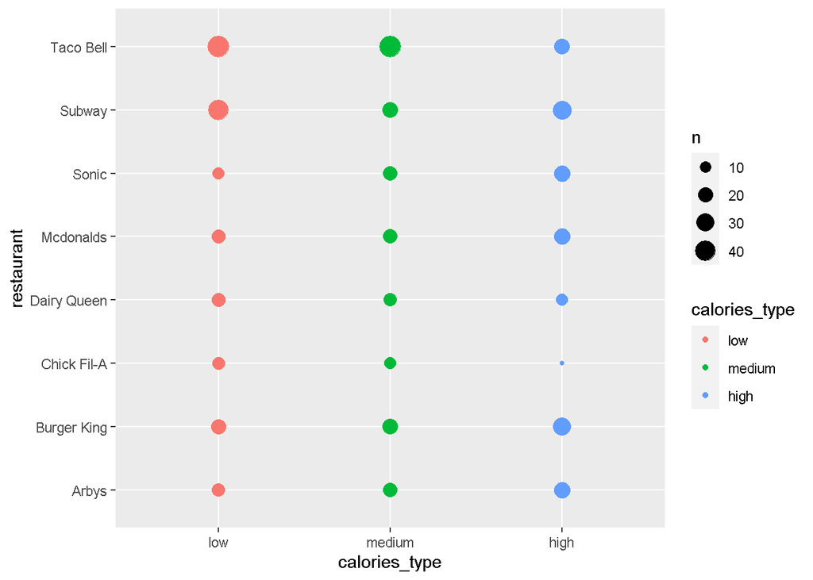

```r
library(knitr)
library(dplyr)
library(ggplot2)

fastfood %>% select ("restaurant", "item", "calories") %>%
  mutate(calories_type = cut_number( calories, n = 3, labels = c("low","medium","high"))) %>%
  arrange(desc(calories)) -> calories_type

calories_type %>% ggplot(aes(restaurant, calories_type, col = calories_type)) + geom_count() + coord_flip()
```

#### 21. Second variable should show the percentage of “trans_fat” in “total_fat”. Add the variable to the data set “trans_fat_percent”.

```r
fastfood %>% mutate(trans_fat_percent = trans_fat/total_fat * 100) %>% select("restaurant", "item", "total_fat", "trans_fat", "trans_fat_percent") -> trans_fat_percent

kable(trans_fat_percent[1:10,])
```

| restaurant | item | total_fat | trans_fat | trans_fat_percent |
| --- | --- | --- | --- | --- |
| Mcdonalds | Artisan Grilled Chicken Sandwich | 7 | 0.0 | 0.000000 |
| Mcdonalds | Single Bacon Smokehouse Burger | 45 | 1.5 | 3.333333 |
| Mcdonalds | Double Bacon Smokehouse Burger | 67 | 3.0 | 4.477612 |
| Mcdonalds | Grilled Bacon Smokehouse Chicken Sandwich | 31 | 0.5 | 1.612903 |
| Mcdonalds | Crispy Bacon Smokehouse Chicken Sandwich | 45 | 0.5 | 1.111111 |
| Mcdonalds | Big Mac | 28 | 1.0 | 3.571429 |
| Mcdonalds | Cheeseburger | 12 | 0.5 | 4.166667 |
| Mcdonalds | Classic Chicken Sandwich | 24 | 0.0 | 0.000000 |
| Mcdonalds | Double Cheeseburger | 21 | 1.0 | 4.761905 |
| Mcdonalds | Double Quarter PounderÂ® with Cheese | 45 | 2.5 | 5.555556 |

```r
View(trans_fat_percent)
```

#### 22. Show the distribution of trans_fat in food items for each type of restautrant.

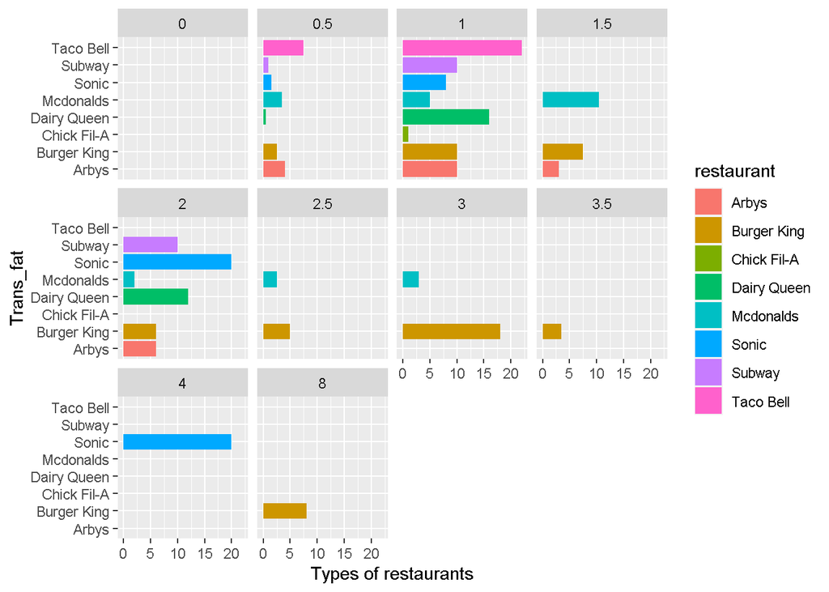

```r
library(knitr)
library(dplyr)
library(ggplot2)

fastfood %>%
  ggplot(aes(restaurant, trans_fat, fill = restaurant)) + geom_col() + facet_wrap(~trans_fat) + coord_flip() + labs( x = "Trans_fat", y = "Types of restaurants")
```

#### 23. Show the average (mean) “total_fat” for each type of restaurant.

```r
fastfood %>% group_by(restaurant) -> average_total_fat

average_total_fat %>% summarise(total_fat = mean(total_fat))
```

```
## # A tibble: 8 x 2
##   restaurant  total_fat
##   <fct>           <dbl>
## 1 Arbys            27.0
## 2 Burger King      36.8
## 3 Chick Fil-A      16.1
## 4 Dairy Queen      28.9
## 5 Mcdonalds        31.8
## 6 Sonic            37.6
## 7 Subway           18.5
## 8 Taco Bell        20.9
```

#### 24. Create a data viz that allows to compare restaurants on this variable “total_fat”

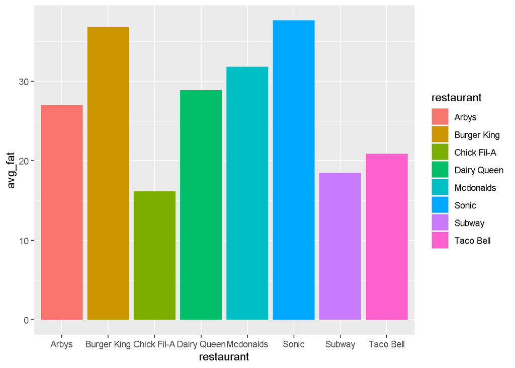

```r
fastfood %>%
  group_by(restaurant) %>% summarize(avg_fat = mean(total_fat)) -> good_rest

View(good_rest)

ggplot(good_rest, aes(restaurant, avg_fat, fill = restaurant)) + geom_col()
```